# 01_security_pretest_clean

Dallas Novakowski

2021-11-28

```r
# actual screening, attention checks and moderate comprehension criteria
data <-  data %>%
  filter(!is.na(age) & !is.na(gender)) %>%
  filter(comp_check == "Deciding whether to try stealing from me" |
           comp_check == "Deciding whether to purchase a security product") %>%
  filter(atn_other2 == "yes" | atn_other2 == "Yes") %>%
  filter(atn_other == "yes" | atn_other == "Yes")

summary(as.factor(data$gender))
```

```
## Female   Male
##     32     34
```

A substantial portion of the sample is lost during data quality screening. From an initial n =108, removing missing age responses yields n = 105, one attention check retains n =80, and (before attention check screening) a strict interpretation of the comprehension check yields n = 42.

After all screening, and using a moderate threshold for comprehension checks, we are left with n=66

# Time spent on pages

How much time have participants spent on each task? Helps to tailor later studies.

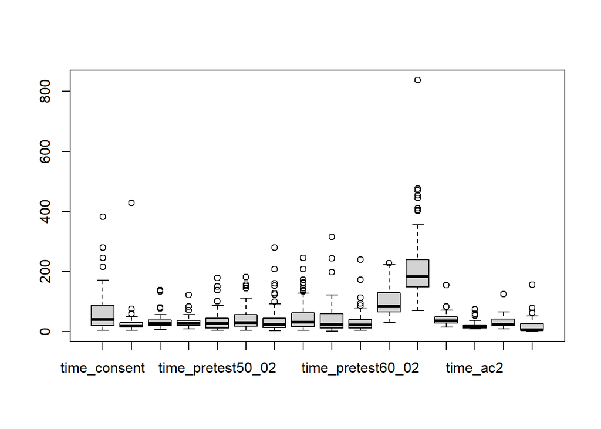

```r
time_data <- data[,time_vars] %>%
   na.omit()


boxplot(time_data)
```

We can see some outliers for time spent. At least for the purposes of estimating time spent, we should treat some outliers to prevent their outsized influence. By trimming them, we assume that these outliers are not “true” values, but rather reflect people drifting to another task.

```r
time_data <- time_data %>%
  filter(time_consent <= 100 & time_dospert <= 550 & time_at_bo <= 20)

nrow(time_data)
```

```
## [1] 31
```

```r
time_means <- sapply(time_data, mean)

time_means
```

```
##      time_consent        time_at_bo time_demographics   time_task_intro
##          38.19355          14.48387          28.38710          26.58065
## time_pretest50_02 time_pretest75_04 time_pretest60_04 time_pretest50_04
##          26.77419          34.09677          30.25806          40.29032
## time_pretest75_02 time_pretest60_02           time_iu      time_dospert
##          27.61290          20.32258          75.96774         177.70968
##          time_ac1          time_ac2           time_cc     time_comments
##          35.58065          15.32258          23.64516           9.83871
```

```r
curate_time <- sum(time_means[c("time_consent","time_at_bo","time_demographics", "time_task_intro", "time_pretest50_02","time_iu","time_iu", "time_ac1","time_ac2","time_cc", "time_comments","time_consent")])
```

After trimming some extreme observations, participants spent an average of 10.42 minutes on the study. Our targeted configuration for our first inequality study, would take an estimated 6.82 minutes.

# Consumption exploration

After attention checks, we are left with 66 participants.

Note: for x_04 conditions, 25 constitutes the maximum possible value for consumption.

[figure not shown]

```r
GeomSplitViolin <- ggproto(
  "GeomSplitViolin",
  GeomViolin,
  draw_group = function(self, data, ..., draw_quantiles = NULL) {
    data <- transform(data,
                      xminv = x - violinwidth * (x - xmin),
                      xmaxv = x + violinwidth * (xmax - x))
    grp <- data[1,'group']
    newdata <- plyr::arrange(
      transform(data, x = if(grp%%2==1) xminv else xmaxv),
      if(grp%%2==1) y else -y
    )
    newdata <- rbind(newdata[1, ], newdata, newdata[nrow(newdata), ], newdata[1, ])
    newdata[c(1,nrow(newdata)-1,nrow(newdata)), 'x'] <- round(newdata[1, 'x'])
    if (length(draw_quantiles) > 0 & !scales::zero_range(range(data$y))) {
      stopifnot(all(draw_quantiles >= 0), all(draw_quantiles <= 1))
      quantiles <- ggplot2:::create_quantile_segment_frame(data, draw_quantiles)
      aesthetics <- data[rep(1, nrow(quantiles)), setdiff(names(data), c("x", "y")), drop = FALSE]
      aesthetics$alpha <- rep(1, nrow(quantiles))
      both <- cbind(quantiles, aesthetics)
      quantile_grob <- GeomPath$draw_panel(both, ...)
      ggplot2:::ggname("geom_split_violin",
                       grid::grobTree(GeomPolygon$draw_panel(newdata, ...), quantile_grob))
    } else {
      ggplot2:::ggname("geom_split_violin", GeomPolygon$draw_panel(newdata, ...))
    }
  }
)

geom_split_violin <- function (mapping = NULL,
                               data = NULL,
                               stat = "ydensity",
                                 position = "identity", ...,
                               draw_quantiles = NULL,
                               trim = TRUE,
                               scale = "area",
                               na.rm = FALSE,
                               show.legend = NA,
                               inherit.aes = TRUE) {
  layer(data = data,
        mapping = mapping,
        stat = stat,
        geom = GeomSplitViolin,
        position = position,
        show.legend = show.legend,
        inherit.aes = inherit.aes,
        params = list(trim = trim,
                      scale = scale,
                      draw_quantiles = draw_quantiles,
                      na.rm = na.rm, ...)
        )
}
```

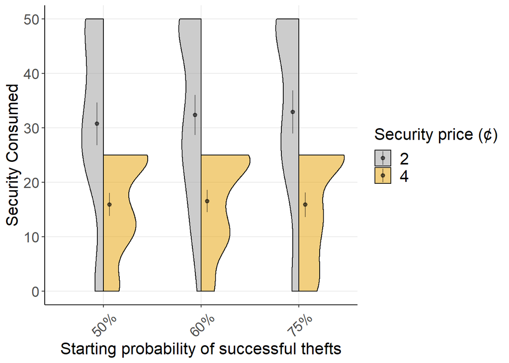

```r
# split violin - adapted from https://debruine.github.io/post/plot-comparison/

summary_data <- data_long %>%
  group_by(prob, cost) %>%
  summarise(
    mean = mean(consumed),
    min = mean(consumed) - qnorm(0.975)*sd(consumed)/sqrt(n()),
    max = mean(consumed) + qnorm(0.975)*sd(consumed)/sqrt(n())
  )
pretest_splitplot <- data_long %>%
  ggplot(aes(y = consumed, x = as.factor(prob), fill = as.factor(cost))) +
  geom_split_violin(color="black", trim=TRUE, alpha = 0.5,
                    width = 1) +
  geom_pointrange(
    data = summary_data,
    aes(as.factor(prob), mean, ymin=min, ymax=max),
    color = "black",
     alpha = 0.5,
    shape = 20, # 95,
    position = position_dodge(width = 0.25)) +
    # geom_boxplot(color = "black",
    #            width = 0.1,
    #            alpha = .1,
    #            position = position_dodge(width=0.5)) +
  ylab("Security Consumed") +
  xlab("Starting probability of successful thefts") +
  labs(fill = "Security price (¢)")+
  ylim(0,50) +
  scale_fill_manual(values=cbPalette)+
  scale_colour_manual(values=cbPalette)+
  scale_x_discrete(labels=c("50" = "50%", "60" = "60%",
                              "75" = "75%")) +
  theme_bw() +
  raincloud_theme

pretest_splitplot
```

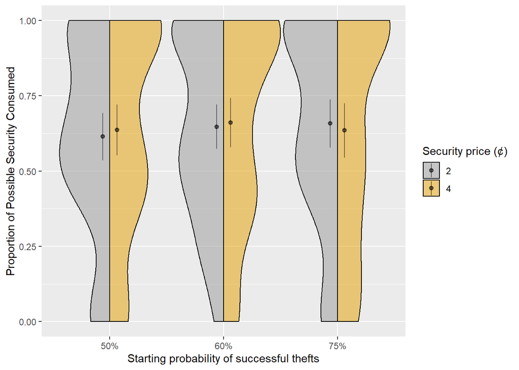

```r
ggsave(here::here("figs", "securitypretest_splitplot.png"), height = 3)
prop_summary_data <- data_long %>%
  group_by(prob, cost) %>%
  summarise(
    mean = mean(prop_consumed),
    min = mean(prop_consumed) - qnorm(0.975)*sd(prop_consumed)/sqrt(n()),
    max = mean(prop_consumed) + qnorm(0.975)*sd(prop_consumed)/sqrt(n())
  )
prop_pretest_splitplot <- data_long %>%
  ggplot(aes(y = prop_consumed, x = as.factor(prob), fill = as.factor(cost))) +
  geom_split_violin(color="black", trim=TRUE, alpha = 0.5,
                    width = 1) +
  geom_pointrange(
    data = prop_summary_data,
    aes(as.factor(prob), mean, ymin=min, ymax=max),
    color = "black",
     alpha = 0.5,
    shape = 20, # 95,
    position = position_dodge(width = 0.25)) +
    # geom_boxplot(color = "black",
    #            width = 0.1,
    #            alpha = .1,
    #            position = position_dodge(width=0.5)) +
  ylab("Proportion of Possible Security Consumed") +
  xlab("Starting probability of successful thefts") +
  labs(fill = "Security price (¢)")+
  ylim(0,1) +
  scale_fill_manual(values=cbPalette)+
  scale_colour_manual(values=cbPalette)+
  scale_x_discrete(labels=c("50" = "50%", "60" = "60%",
                              "75" = "75%"))

prop_pretest_splitplot
```

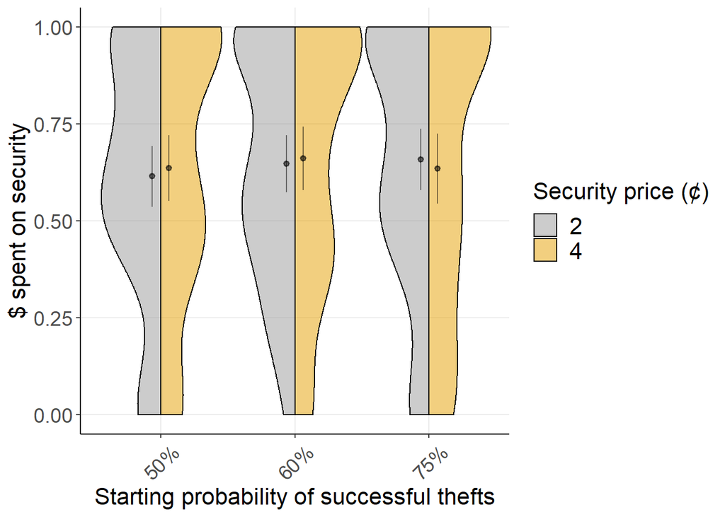

```r
ggsave(here::here("figs", "prop_pretest_splitplot.png"), height = 3)
spending_summary_data <- data_long %>%
  group_by(prob, cost) %>%
  summarise(
    mean = mean(security_spending),
    min = mean(security_spending) - qnorm(0.975)*sd(security_spending)/sqrt(n()),
    max = mean(security_spending) + qnorm(0.975)*sd(security_spending)/sqrt(n())
  )
spending_pretest_splitplot <- data_long %>%
  ggplot(aes(y = security_spending, x = as.factor(prob), fill = as.factor(cost))) +
  geom_split_violin(color="black", trim=TRUE, alpha = 0.5,
                    width = 1,
                    # position = position_nudge(x = -.005)
                    ) +
  geom_pointrange(
    data = spending_summary_data,
    aes(as.factor(prob), mean, ymin=min, ymax=max),
    color = "black",
     alpha = 0.5,
    shape = 20, # 95,
    position = position_dodge(width = 0.25),
    show.legend=FALSE) +
    # geom_boxplot(color = "black",
    #            width = 0.1,
    #            alpha = .1,
    #            position = position_dodge(width=0.5)) +
  ylab("$ spent on security") +
  xlab("Starting probability of successful thefts") +
  labs(fill = "Security price (¢)")+
  ylim(0,1) +
  scale_fill_manual(values=cbPalette)+
  scale_colour_manual(values=cbPalette)+
  scale_x_discrete(labels=c("50" = "50%", "60" = "60%",
                              "75" = "75%")) +
    theme_bw() +
  raincloud_theme

spending_pretest_splitplot
```

```r
ggsave(here::here("figs", "spending_pretest_splitplot.png"), height = 3)
# data_long$spent2 <- paste0(data_long$security_spending, "2") # create a second almost identical variable
#
# ggplot(data_long,aes(security_spending, value)) +
#   geom_beeswarm(aes(spent2),priority='random',cex=2.5) +
#
#
# spent_rain <- ggplot(data = data_long, aes(y = security_spending, x = as.factor(prob), fill = as.factor(cost))) +
#   geom_flat_violin(alpha = .8) +
#     geom_boxplot(width = .1, guides = FALSE, outlier.shape = NA, alpha = 0.5) +
#     geom_pointrange(
#     data = spending_summary_data,
#     aes(as.factor(prob), mean, ymin=min, ymax=max),
#     color = "black",
#      alpha = 0.5,
#     shape = 20, # 95,
#     position = position_dodge(width = 0.25)) +
#
#
#   guides(fill = FALSE) +
#   guides(color = FALSE) +
#   scale_fill_manual(values=cbPalette)+
#   scale_colour_manual(values=cbPalette) +
# # coord_flip() +
#   theme_bw() +
#   raincloud_theme
#
#
# spent_rain
```

```r
# GeomBurger <- ggproto(
#   "GeomBurger",
#   GeomViolin,
#   draw_group = function(self, data, ..., draw_quantiles = NULL) {
#     data <- transform(data,
#                       xminv = x - violinwidth * (x - xmin),
#                       xmaxv = x + violinwidth * (xmax - x))
#     grp <- data[1,'group']
#     newdata <- plyr::arrange(
#       transform(data, x = if(grp%%2==1) xminv else xmaxv),
#       if(grp%%2==1) y else -y
#     )
#     newdata <- rbind(newdata[1, ], newdata, newdata[nrow(newdata), ], newdata[1, ])
#     newdata[c(1,nrow(newdata)-1,nrow(newdata)), 'x'] <- round(newdata[1, 'x'])
#   }
# )
#
# geom_burger <- function (mapping = NULL,
#                                data = NULL,
#                                stat = "ydensity",
#                                  position = "identity", ...,
#                                draw_quantiles = NULL,
#                                trim = TRUE,
#                                scale = "area",
#                                na.rm = FALSE,
#                                show.legend = NA,
#                                inherit.aes = TRUE) {
#   layer(data = data,
#         mapping = mapping,
#         stat = stat,
#         geom = GeomBurger,
#         position = position,
#         show.legend = show.legend,
#         inherit.aes = inherit.aes,
#         params = list(trim = trim,
#                       scale = scale,
#                       draw_quantiles = draw_quantiles,
#                       na.rm = na.rm, ...)
#         )
# }
```

[output not shown]